# Stat_490_Paper

Andrew Maloney

5/5/2020

## Consecutive Matching Striae

### Produced in R Markdown

(Figure 1): Regular image of scanned Bullet

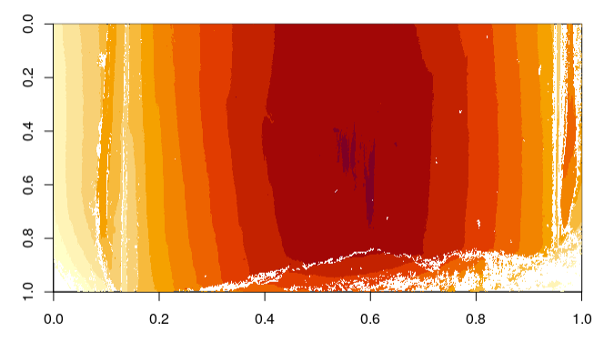

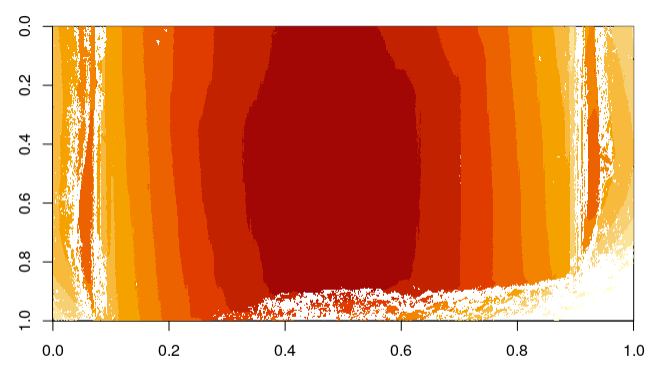

(Figure 2): Image of scanned Bullet with Reduced Pixels

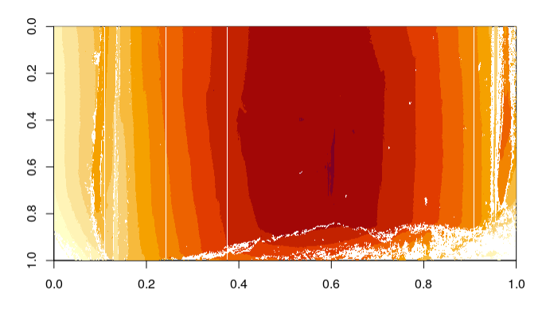

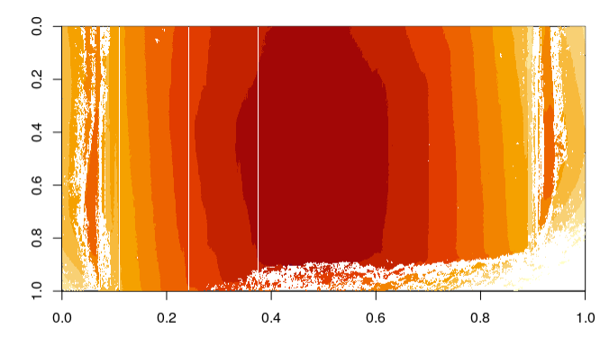

- When comparing bullet scans that were down sampled versus bullet scans that were not down sampled, we see that down sampling removes some tank rash and other markings from the bullet’s surface. Thus, resulting in smoother images of the scanned bullets.
- We are now able to analyze the surface scan, by taking a cross section of the surface measurements. This can be performed using the x3p_crosscut_optimize() function and then next the x3p_crosscut() function. Both of which are in the bulletxtrctr R package. *Note: We will refer to the surface scan as a land impression from now on.* When plotting the crosscuts we are left with a side profile of the land impressions. Notice the shape of the side profile, it resembles a perfect semi circle. If we think about the shape of a bullet and look at surface of the bullet outside its casing, we can take a pencil and sketch a 180 degree line along the bullet. Which will give us the same semi circular shape. Also notice the two hills on the left and right side of the cross sections. These hills are known as shoulders and at the valleys of these shoulders is where the land impression starts and ends. The shoulders contain no useful information to date and are removed(See Figure 3).

(Figure 3): Side Profile of land impression before correctly identifying groove cutoffs

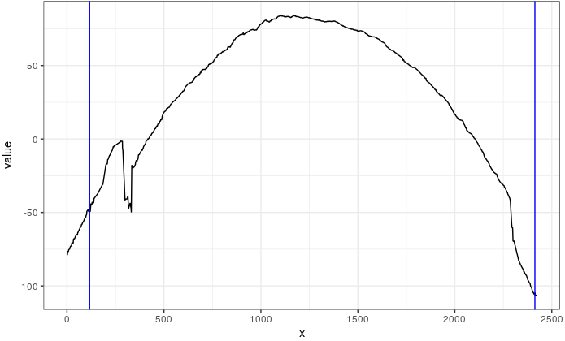

- We begin the process of removing the shoulders. First we identify the shoulder locations of each land impression. Second we smooth the land impression. We then remove the shoulders of the land impression by specifying the left and right shoulder cutoffs. Currently this process is trying to be automated using the cc_locate_grooves() function in the bulletxtrctr package but for this study we manually removed the shoulders of the smoothed land impression using a shiny app(See Figure 4).

(Figure 4): Shiny displaying the new groove cutoffs.

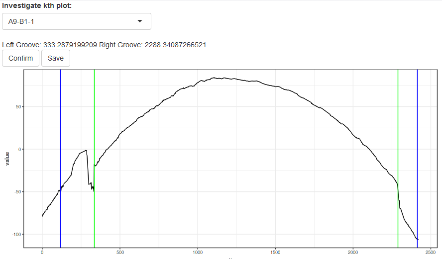

- After we have identified the groove cutoffs we look for the lowest stable region for each land impression and extract the signatures. The signatures can be obtained using the cc_get_signature() function in the bulletxtrctr package.
- In the beginning of this paper we talked about bullets being numerically characterized, which we said were features. One of these features is CMS, also known as consecutive matching striae. We are now able to extract the CMS and all the other features associated with a bullets land impression. We first smooth the signatures(See Figure 8 & 9), identifiy peaks and valleys of each signature(See Figure 10), and align every signature with eachother(See Figure 11). When the two signatures are aligned we are able to identify the matching peaks and valleys which coincide to the striation marks left on a bullet’s surface after being fired(See figure 11). This is done by using the sig_aligned() function in the bulletxtrctr package. Notice the word “striation,” that’s right these are our consecutive matching striae. We can calculate the consecutive matching striae using the sig_cms_max() function in the bulletxtrctr package.

(Figure 8): Show Smoothed Vs Non Smoothed(span = default)

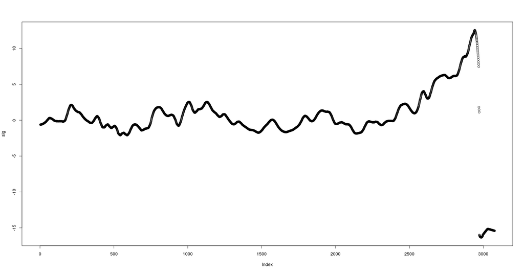

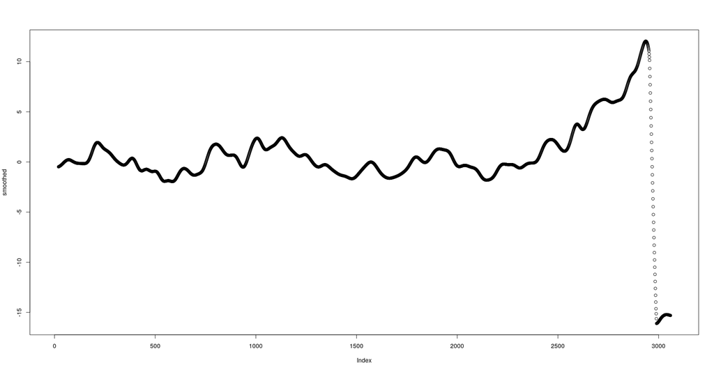

(Figure 9): Smoothing Overlayed

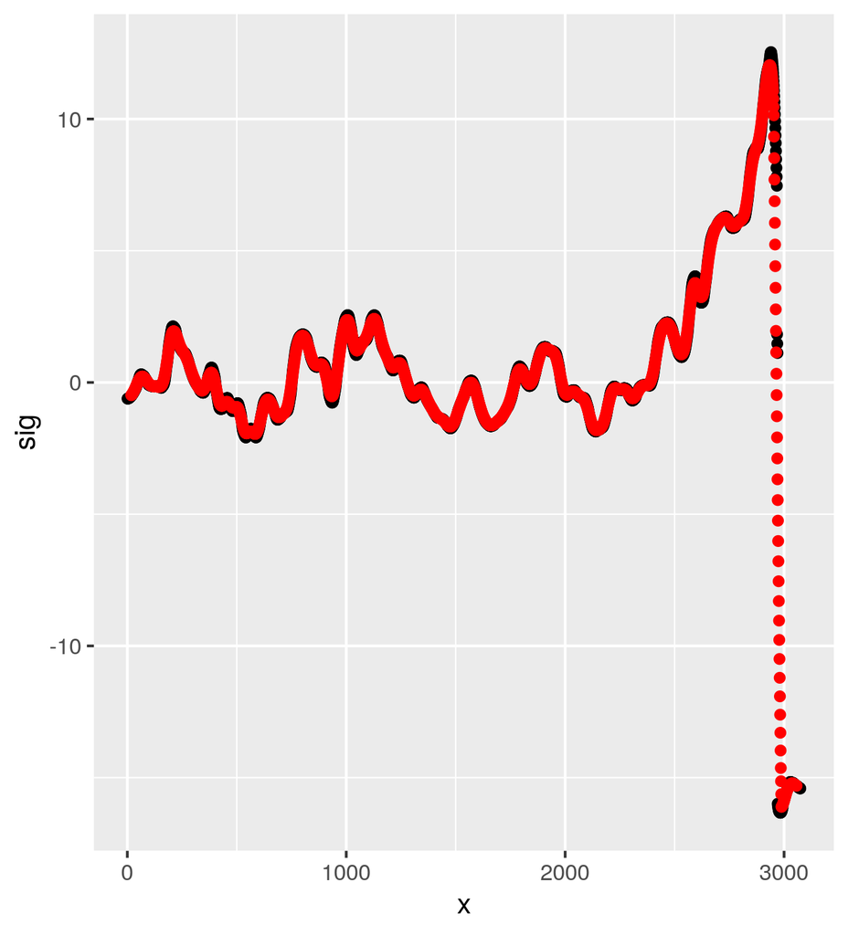

(Figure 10): Show identified peaks and valleys

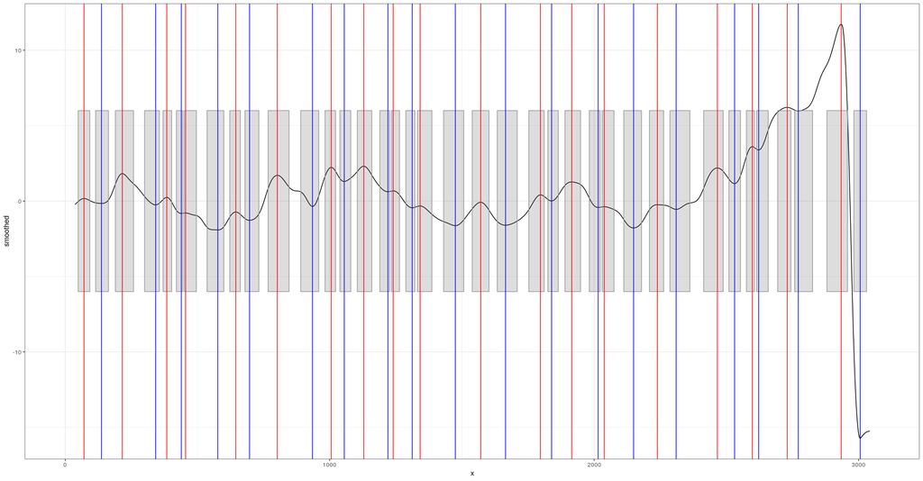

(Figure 11): Show Aligned Signatures

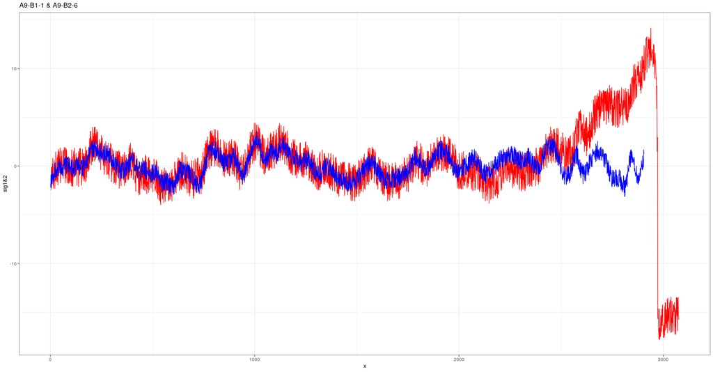

- We explore the maximum number of CMS using different values for the span parameter in sig_cms_max(). We run 8 different spans and compare the Maximum number of CMS

## Summary Statistics

### Same_Comparisons_Removed using dataframe where no sampling was performed

```r
#Same_Comparisons_Removed <- Same_Comparisons_Removed %>% select(-X)

head(Same_Comparisons_Removed, 8)
```

```
##   X Span Min X1st.Qu. Median  Mean X3rd.Qu. Max.
## 1 1   15   0        2      3 2.872        4   34
## 2 2   25   0        2      2 2.827        3   37
## 3 3   35   0        2      2 2.776        3   32
## 4 4   45   0        2      2 2.745        3   37
## 5 5   55   0        1      2 2.685        3   34
## 6 6   65   0        1      2 2.569        3   34
## 7 7   75   0        1      2 2.442        3   25
## 8 8   85   0        1      2 2.349        3   23
```

### Same_Comparisons Removed using dataframe where sampling was performed

```r
head(Same_Comparisons_Removed_Samp, 8)
```

```
## # A tibble: 8 x 7
##    Span  Min. `1st Qu.` Median  Mean `3rd Qu.`  Max.
##   <dbl> <dbl>     <dbl>  <dbl> <dbl>     <dbl> <dbl>
## 1    15     0         2      2  2.77         3    38
## 2    25     0         2      2  2.70         3    37
## 3    35     0         1      2  2.51         3    38
## 4    45     0         1      2  2.32         3    22
## 5    55     0         1      2  2.22         3    21
## 6    65     0         1      2  2.12         3    20
## 7    75     0         1      2  1.98         3    16
## 8    85     0         1      2  1.87         3    15
```

- We first removed Same Land Comparisons from both the nonsampled and sampled dataframes. This is to ensure we remove bullet land comparisons we know are already matches. We can think of these as sorta outliers and they could have negative effects when it comes to our future random forest model’s performance when distinguishing the majority and minority class values.
- Looking at the CMS statistics for Same_Comparisons_Removed the lower values of span have higher mean and max statistics. Looking at the CMS statistics for Same_Comparisons_Removed_Samp the lower values of the span have higher mean and max statistics. Comparing the CMS values for bullet land scans that did not have sampling performed with bullet land scans that did have sampling performed; we see that sampling tends to lower the overall mean cms value. Looking at the Max CMS values for bullet land scans where sampling was performed we see higher CMS values at the lower values of span compared to the bullet land scans that did not have sampling performed on them. This could make our previous statement less justifiable. These results suggest we perform less smoothing or at least avoid very high span values when we smooth.

Class Seperatability based on CMS span values

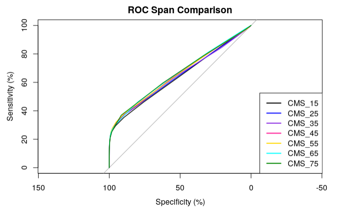

Distinct

## AUC Scores for dataframe where sampling was not performed

Span of 15: Area under the curve: 0.6414

Span of 25: Area under the curve: 0.6498

Span of 35: Area under the curve: 0.6487

Span of 45: Area under the curve: 0.6577

Span of 55: Area under the curve: 0.6611

Span of 65: Area under the curve: 0.6614

Span of 75: Area under the curve: 0.6606

Span of 85: Area under the curve: 0.6602

## AUC Scores for dataframe where sampling was performed

Span of 15: Area under the curve: 0.6496

Span of 25: Area under the curve: 0.6623

Span of 35: Area under the curve: 0.6587

Span of 45: Area under the curve: 0.6519

Span of 55: Area under the curve: 0.6537

Span of 65: Area under the curve: 0.6487

Span of 75: Area under the curve: 0.644

Span of 85: Area under the curve: 0.6378

- Notice, for all the span values we see slight separability. The CMS feature does seem to explain some of the models ability to distinquish between Matchs and Non-matches. All AUC scores were in the mid 60’s. AUC scores differ between bullet land scans where sampling was not performed and bullet land scans where sampling was peformed. For bullets where sampling was not performed we see a span of 65 having the highest AUC value and for bullets where sampling was performed we see a span of 25 having the highest AUC value.

## Model Summary RF

Random Forest

### Span 55 where FALSE is the positive class value

#### Same Comparisons kept

```
Precision = 7357/(7357+187) = .9752

Recall = 7357/(7357+133) = 0.9822

F-measure(Harmonic Mean) = 2(7357)/(2(7357)+187+133) = 0.9787

CBA_p = 7357/max{7357+187, 7357+133} = .9752

CBA_n = 163/max{163+187, 163+133} = 0.4657

CBA = (CBA_p + CBA_n)/2 = 0.7204
```

———–Reference————

Prediction FALSE TRUE

```
FALSE  7357  187

TRUE    133  163
```

### Span 55 where FALSE is the positive class value

#### Same comparisons removed

```
Precision = 3747/(3747+104) = 0.9729

Recall = 3747/(3747+1) = 0.9997

F-measure(Harmonic Mean) = 2(3747)/(2(3747)+104+1) = 0.9861

CBA_p = 3747/max{3747+104, 3747+1} = 0.9729

CBA_n = 48/max{48+104, 48+1} = 0.3157

CBA = (CBA_p + CBA_n)/2 = 0.6443
```

———–Reference————

Prediction FALSE TRUE

```
FALSE  3747  104

TRUE      1   48
```

Accuracy : 0.9731

#### Span 55 sample run where FALSE is the positive class value

#### Same comparisons kept

```
Precision = 7338/(7338+205) = 0.9728

Recall = 7338/(7338+145) = 0.9806

F-measure(Harmonic Mean) = 2(7338)/(2(7338)+205+145) = 0.9767

CBA_p = 7338/max{7338+205, 7338+145} = 0.9728

CBA_n = 152/max{152+205, 152+145} = 0.4257

CBA = (CBA_p + CBA_n)/2 = 0.6992
```

———–Reference————

Prediction FALSE TRUE

```
FALSE  7338  205

TRUE    145  152
```

#### Span 55 sample run where FALSE is the positive class value

#### Same comparisons removed

```
Precision = 3738/(3738+121) = 0.9686

Recall = 3738/(3738+5) = 0.9986

F-measure(Harmonic Mean) = 2(3738)/(2(3738)+121+5) = 0.9834

*CBA_p = 3738/max{3738+121, 3738+5} = 0.9686*

*CBA_n = 36/maax{36+121, 36+5} = 0.2292*

CBA = (CBA_p + CBA_n)/2 = 0.5989
```

———–Reference————-

Prediction FALSE TRUE

```
FALSE  3738  121

TRUE      5   36
```

Accuracy : 0.9677

## Conclusion

- We explored the CMS feature and sought ways to improve it. The span value does play an impact on the number of consecutive matching striation marks. Span values and sampling also play a role when it comes to machine learning model performance but do not seem to increase the overall value of consecutive matching striae. This leads us to believe the current way CMS is calculated may need to be adjusted. When exploring two aligned signatures there was strong evidence for higher CMS values than what was actually calculated. This was found by individually looking at aligned signature plot and observing the matching peaks and values. Currently the CMS values outputed seems to be too low for some bullet comparisons.

## Code Appendix

```r
image(Phoenix$x3p[[7]])
ggsave("No_Sampling.png")

Phoenix <- Phoenix %>% mutate(x3p = map(x3p, sample_x3p, m = 2)) # Down Sampling

image(Phoenix$x3p[[7]])
ggsave("Sampling.png")
```

```r
Phoenix <- Phoenix %>%
  mutate(CrossSection = map_dbl(x3p, x3p_crosscut_optimize))
```

```r
Phoenix <- Phoenix %>%
  mutate(CrossCut = map2(.x = x3p, .y = CrossSection, .f = x3p_crosscut))

crosscuts_phoenix <- select(Phoenix, -path, -x3p) %>%
      tidyr::unnest(CrossCut)
```

```r
library(shiny)
if (file.exists(saved_grooves_location_Phoenix)) {
  Phoenix$Grooves <- readRDS(saved_grooves_location_Phoenix)
}
if (interactive()) { # only run when you're manually running chunks... don't run when the whole document is compiled.
  shinyApp(
    ui = fluidPage(
      selectInput("k", "Investigate kth plot:",
                  selected = 1,
                  choices = (1:length(Phoenix$Grooves)) %>% set_names(Phoenix$id)
      ),
      textOutput("groovelocations"),
      actionButton("confirm", "Confirm"),
      actionButton("save", "Save"),
      plotOutput("groovePlot", click = "plot_click"),
      verbatimTextOutput("info")
    ),

    server = function(input, output, session) {
      output$groovePlot <- renderPlot({
        k <- as.numeric(input$k)
        p <- Phoenix$Grooves[[k]]$plot

        p
      })
      output$groovelocations <- renderText({
        paste(
          "Left Groove: ", Phoenix$Grooves[[as.numeric(input$k)]]$groove[1],
          " Right Groove: ", Phoenix$Grooves[[as.numeric(input$k)]]$groove[2]
        )
      })
      observeEvent(input$confirm, {
        cat(paste(Phoenix$id[as.numeric(input$k)], "\n"))
        updateSelectInput(session, "k", "Investigate kth plot:",
                          selected = as.numeric(input$k) + 1,
                          choices = (1:length(Phoenix$Grooves)) %>% set_names(Phoenix$id)
        )
      })
      observeEvent(input$save, {
        saveRDS(Phoenix$Grooves, file = saved_grooves_location_Phoenix)
        message("groove data saved\n")
      })

      observeEvent(input$plot_click, {
        k <- as.numeric(input$k)
        xloc <- input$plot_click$x

        gr <- Phoenix$Grooves[[k]]$groove
        if (abs(gr[1] - xloc) < abs(gr[2] - xloc)) {
          Phoenix$Grooves[[k]]$groove[1] <<- xloc
        } else {
          Phoenix$Grooves[[k]]$groove[2] <<- xloc
        }
        output$groovePlot <- renderPlot({
          k <- as.numeric(input$k)
          p <- Phoenix$Grooves[[k]]$plot +
            geom_vline(xintercept = Phoenix$Grooves[[k]]$groove[1], colour = "green") +
            geom_vline(xintercept = Phoenix$Grooves[[k]]$groove[2], colour = "green")

          p
        })
      })
      output$info <- renderText({
        paste0("x=", input$plot_click$x, "\ny=", input$plot_click$y)
      })
    },
    options = list(height = 500)
  )
  saveRDS(Phoenix$Grooves, file = saved_grooves_location_Phoenix)
} else {
  if (!file.exists(saved_grooves_location_Phoenix)) {
    message("run script in interactive mode to fix grooves")
  } else {
    Phoenix$Grooves <- readRDS(saved_grooves_location_Phoenix)
  }
}
```

```r
Phoenix <- Phoenix %>%
 mutate(Signatures = future_map2(.x = CrossCut, .y = Grooves, .f = cc_get_signature, span = 0.75, span2 = .03))

 Signatures_Phoenix <- Phoenix %>%
  select(id, Barrel, Bullet, Land, Signatures) %>%
   tidyr::unnest()
```

```r
Phoenix_Comparisons <- crossing(Bullet1 = Phoenix$id, Bullet2 = Phoenix$id) %>%
  left_join(nest(Phoenix, -id) %>% magrittr::set_names(c("Bullet1", "Bullet1_data"))) %>%
  left_join(nest(Phoenix, -id) %>% magrittr::set_names(c("Bullet2", "Bullet2_data")))
```

```r
get_sig <- function(data) {
  map(data$Signatures, "sig")
}
Phoenix_Comparisons <- Phoenix_Comparisons %>%
  mutate(sig1 = map(Bullet1_data, get_sig), sig2 = map(Bullet2_data, get_sig))

Phoenix_Comparisons <- Phoenix_Comparisons %>%
  select(-Bullet1_data, -Bullet2_data)

Phoenix_Comparisons <- Phoenix_Comparisons %>%
  mutate(Aligned = map2(sig1, sig2, ~sig_align(unlist(.x), unlist(.y))))
```

```r
Phoenix_Comparisons <- Phoenix_Comparisons %>%
 mutate(Striae = map(Aligned, sig_cms_max, span = 15))

Phoenix_Comparisons <- Phoenix_Comparisons %>%
  mutate(features = map2(.x = Aligned, .y = Striae, .f = extract_features_all, resolution = resolution_p))

Phoenix_Comparisons <- Phoenix_Comparisons_15 %>%
  tidyr::unnest(features)
```

*Span of 15:*

Min. 1st Qu. Median Mean 3rd Qu. Max.

0.000 2.000 3.000 3.141 4.000 73.000 [1*]

0.000 2.000 3.000 2.872 4.000 34.000 [2*]

*Span of 25:*

Min. 1st Qu. Median Mean 3rd Qu. Max.

0.000 2.000 3.000 3.062 3.000 62.000 [1]

0.000 2.000 2.000 2.827 3.000 37.000 [2]

*Span of 35:*

Min. 1st Qu. Median Mean 3rd Qu. Max.

0.000 2.000 2.000 2.974 3.000 56.000 [1]

0.000 2.000 2.000 2.776 3.000 32.000 [2]

*Span of 45:*

Min. 1st Qu. Median Mean 3rd Qu. Max.

0.000 2.000 2.000 2.915 3.000 47.000 [1]

0.000 2.000 2.000 2.745 3.000 37.000 [2]

*Span of 55:*

Min. 1st Qu. Median Mean 3rd Qu. Max.

0.000 1.000 2.000 2.832 3.000 41.000 [1]

0.000 1.000 2.000 2.685 3.000 34.000 [2]

*Span of 65:*

Min. 1st Qu. Median Mean 3rd Qu. Max.

0.000 1.000 2.000 2.698 3.000 37.000 [1]

0.000 1.000 2.000 2.569 3.000 34.000 [2]

*Span of 75:*

Min. 1st Qu. Median Mean 3rd Qu. Max.

0.000 1.000 2.000 2.557 3.000 34.000 [1]

0.000 1.000 2.000 2.442 3.000 25.000 [2]

*Span of 85:*

Min. 1st Qu. Median Mean 3rd Qu. Max.

0.000 1.000 2.000 2.451 3.000 30.000 [1]

0.000 1.000 2.000 2.349 3.000 23.000 [2]